# Lecture 7: Omitted and irrelevant regressors

Economics 527: Econometric Methods

Vadim Marmer, UBC

# Long and short regressions

## Model and two estimators of $\beta_1$

- Two blocks of regressors, $k_1 + k_2 = k$:
  $$Y = \underset{n\times k_1}{X_1}\ \underset{k_1\times 1}{\beta_1} + \underset{n\times k_2}{X_2}\ \underset{k_2\times 1}{\beta_2} + U, \qquad X = [\, X_1 \ \ X_2 \,]$$
- Assumptions 2, 3 and 4:
  $$\mathrm{E}\left[U \mid X_1, X_2\right] = 0, \qquad \mathrm{Var}\left(U \mid X_1, X_2\right) = \sigma^2 I_n, \qquad \operatorname{rank}\left(X\right) = k$$
- “Long” regression $Y \mid X_1, X_2$, controlling for $X_2$ (FWL):
  $$\hat\beta_1 = (X_1^\top M_2 X_1)^{-1} X_1^\top M_2 Y, \qquad M_2 = I_n - X_2 (X_2^\top X_2)^{-1} X_2^\top$$
- “Short” regression $Y \mid X_1$, not controlling for $X_2$:
  $$\tilde\beta_1 = (X_1^\top X_1)^{-1} X_1^\top Y$$

## Short against long in the sample

- Long regression’s fit (third lecture):
  $$Y = X_1 \hat\beta_1 + X_2 \hat\beta_2 + \hat U$$
- Substitute into $\tilde\beta_1$:
  $$\begin{aligned}
  \tilde\beta_1 &= (X_1^\top X_1)^{-1} X_1^\top Y \\
  &= (X_1^\top X_1)^{-1} X_1^\top \big( X_1 \hat\beta_1 + X_2 \hat\beta_2 + \hat U \big) \\
  &= \hat\beta_1 + (X_1^\top X_1)^{-1} X_1^\top X_2 \hat\beta_2 + (X_1^\top X_1)^{-1} \underbrace{X_1^\top \hat U}_{=\,0} \\
  &= \boxed{\ \hat\beta_1 + (X_1^\top X_1)^{-1} X_1^\top X_2 \hat\beta_2\ } \\
  &\ne \hat\beta_1 \quad \text{in general} \\
  \tilde\beta_1 &= \hat\beta_1 \quad \text{if } X_1^\top X_2 = 0
  \end{aligned}$$

# Omitting a relevant regressor

## Signal, bias and noise

- True model, estimated by the short regression $Y \mid X_1$:
  $$Y = X_1 \beta_1 + X_2 \beta_2 + U, \qquad \beta_2 \ne 0$$
- Substitute the true model into $\tilde\beta_1$:
  $$\begin{aligned}
  \tilde\beta_1 &= (X_1^\top X_1)^{-1} X_1^\top Y \\
  &= (X_1^\top X_1)^{-1} X_1^\top \big( X_1 \beta_1 + X_2 \beta_2 + U \big) \\
  &= \underbrace{\beta_1}_{\text{signal}} + \underbrace{(X_1^\top X_1)^{-1} X_1^\top X_2 \beta_2}_{\text{bias}} + \underbrace{(X_1^\top X_1)^{-1} X_1^\top U}_{\text{noise}}
  \end{aligned}$$
- Conditional mean of $\tilde\beta_1$, by Assumption 2:
  $$\begin{aligned}
  \mathrm{E}\left[\tilde\beta_1 \mid X_1, X_2\right] &= \beta_1 + (X_1^\top X_1)^{-1} X_1^\top X_2 \beta_2 + (X_1^\top X_1)^{-1} X_1^\top \underbrace{\mathrm{E}\left[U \mid X_1, X_2\right]}_{=\,0} \\
  &= \boxed{\ \beta_1 + \underbrace{(X_1^\top X_1)^{-1} X_1^\top X_2 \beta_2}_{\text{bias}}\ } \\
  &\ne \beta_1 \quad \text{in general}
  \end{aligned}$$
- Bias $= 0$ if:
  $$\begin{aligned}
  \text{1.}\quad & \beta_2 = 0 \\
  \text{2.}\quad & X_1^\top X_2 = 0
  \end{aligned}$$

## Example: return to education, ability omitted

- Wage equation, $k_1 = k_2 = 1$:
  $$\ln \text{Wage}_i = \underbrace{\text{Education}_i}_{X_{i,1}}\, \beta_1 + \underbrace{\text{Ability}_i}_{X_{i,2}}\, \beta_2 + U_i$$
- $\beta_1$: return to education; $\beta_2 > 0$.
- Suppose $X_1^\top X_2 > 0$:
  $$X_1^\top X_2 = \sum_{i=1}^n \text{Education}_i \cdot \text{Ability}_i \ > 0$$
- Sign of the bias, three positive factors:
  $$\begin{aligned}
  \text{Bias} &= \underbrace{(X_1^\top X_1)^{-1}}_{+}\ \underbrace{X_1^\top X_2}_{+}\ \overset{+}{\beta_2} \ > 0 \\
  \Longrightarrow\quad & \mathrm{E}\left[\tilde\beta_1 \mid X_1, X_2\right] > \beta_1
  \end{aligned}$$
- Return to education over-estimated.

# Variances of the long and short estimators

## Two conditional variances

- We will use, for $\Gamma$ a function of $X_1, X_2$:
  $$\mathrm{Var}\left(\Gamma U \mid X_1, X_2\right) = \Gamma\, \mathrm{Var}\left(U \mid X_1, X_2\right)\, \Gamma^\top$$
- Short regression, by Assumption 3:
  $$\begin{aligned}
  \mathrm{Var}\left(\tilde\beta_1 \mid X_1, X_2\right) &= \mathrm{Var}\left(\beta_1 + (X_1^\top X_1)^{-1} X_1^\top X_2 \beta_2 + (X_1^\top X_1)^{-1} X_1^\top U \mid X_1, X_2\right) \\
  &= \mathrm{Var}\left((X_1^\top X_1)^{-1} X_1^\top U \mid X_1, X_2\right) \\
  &= (X_1^\top X_1)^{-1} X_1^\top\, \underbrace{\mathrm{Var}\left(U \mid X_1, X_2\right)}_{=\,\sigma^2 I_n}\, X_1 (X_1^\top X_1)^{-1} \\
  &= \sigma^2 (X_1^\top X_1)^{-1}
  \end{aligned}$$
- Long regression:
  $$\begin{aligned}
  \mathrm{Var}\left(\hat\beta_1 \mid X_1, X_2\right) &= \mathrm{Var}\left(\beta_1 + (X_1^\top M_2 X_1)^{-1} X_1^\top M_2 U \mid X_1, X_2\right) \\
  &= \mathrm{Var}\left((X_1^\top M_2 X_1)^{-1} X_1^\top M_2 U \mid X_1, X_2\right) \\
  &= (X_1^\top M_2 X_1)^{-1} X_1^\top M_2\, \sigma^2 I_n\, M_2 X_1 (X_1^\top M_2 X_1)^{-1} \quad (M_2^\top = M_2) \\
  &= \sigma^2 (X_1^\top M_2 X_1)^{-1} \underbrace{X_1^\top M_2 M_2 X_1}_{=\,X_1^\top M_2 X_1} (X_1^\top M_2 X_1)^{-1} \\
  &= \sigma^2 (X_1^\top M_2 X_1)^{-1}
  \end{aligned}$$

## Proof, step 1: inverses to matrices

- Scalars $a, b > 0$:
  $$b - a \ge 0 \quad \Longleftrightarrow \quad \frac{1}{a} - \frac{1}{b} \ge 0$$
- **Claim** (homework). For $A$, $B$ p.d.:
  $$B - A \ge 0 \quad \Longleftrightarrow \quad A^{-1} - B^{-1} \ge 0$$
- Apply the homework claim, $A$ and $B$ p.d. by Assumption 4:
  $$\begin{aligned}
  & \underbrace{(X_1^\top M_2 X_1)^{-1}}_{A^{-1}} - \underbrace{(X_1^\top X_1)^{-1}}_{B^{-1}} \ \ge\ 0 \\
  \Longleftrightarrow\quad & \underbrace{X_1^\top X_1}_{B} - \underbrace{X_1^\top M_2 X_1}_{A} \ \ge\ 0
  \end{aligned}$$

## Proof, step 2: $X_1^\top P_2 X_1$ p.s.d.

- Rewrite the difference, $I_n - M_2 = P_2$:
  $$\begin{aligned}
  X_1^\top X_1 - X_1^\top M_2 X_1 &= X_1^\top (I_n - M_2) X_1 \\
  &= X_1^\top P_2 X_1, \qquad P_2 = X_2 (X_2^\top X_2)^{-1} X_2^\top
  \end{aligned}$$
- $P_2$ p.s.d. $\Longrightarrow$ quadratic form of $X_1^\top P_2 X_1$ p.s.d., for $c \in \mathbb{R}^{k_1}$:
  $$c^\top X_1^\top P_2 X_1 c = w^\top P_2 w \ \ge\ 0, \qquad w = X_1 c$$
- Therefore:
  $$\begin{aligned}
  & X_1^\top X_1 - X_1^\top M_2 X_1 = X_1^\top P_2 X_1 \ \ge\ 0 \\
  \Longrightarrow\quad & (X_1^\top M_2 X_1)^{-1} - (X_1^\top X_1)^{-1} \ \ge\ 0 \quad \text{(step 1)} \\
  \Longrightarrow\quad & \boxed{\ \mathrm{Var}\left(\hat\beta_1 \mid X_1, X_2\right) - \mathrm{Var}\left(\tilde\beta_1 \mid X_1, X_2\right) \ \ge\ 0\ }
  \end{aligned}$$

## Why controlling for $X_2$ increases the variance

- $X_1^\top M_2 X_1$ in terms of $\tilde X_1$:
  $$\begin{aligned}
  X_1^\top M_2 X_1 &= \underbrace{X_1^\top M_2^\top}_{\tilde X_1^\top}\, \underbrace{M_2 X_1}_{\tilde X_1} \quad \text{(symmetric, idempotent)} \\
  &= \tilde X_1^\top \tilde X_1
  \end{aligned}$$
- $\tilde X_1 = M_2 X_1$: residual from regressing $X_1$ on $X_2$.
- Conditional variances of $\hat\beta_1$ and $\tilde\beta_1$:
  $$\begin{aligned}
  \mathrm{Var}\left(\hat\beta_1 \mid X_1, X_2\right) &= \sigma^2 (X_1^\top M_2 X_1)^{-1} \\
  &= \sigma^2 (\tilde X_1^\top \tilde X_1)^{-1} \\
  \mathrm{Var}\left(\tilde\beta_1 \mid X_1, X_2\right) &= \sigma^2 (X_1^\top X_1)^{-1}
  \end{aligned}$$
- $X_1^\top X_1$ against $\tilde X_1^\top \tilde X_1$, from step 2:
  $$X_1^\top X_1 - \tilde X_1^\top \tilde X_1 \ \ge\ 0$$
- $\tilde X_1^\top \tilde X_1$: variation of $X_1$ not explained by $X_2$.
- Adding $X_2 \ \Longrightarrow\$ variance $\uparrow$.

## Bias against variance

- If $\beta_2 \ne 0$:
  $$\begin{aligned}
  \hat\beta_1 &:\ \text{unbiased, larger variance} \\
  \tilde\beta_1 &:\ \text{biased in general, smaller variance}
  \end{aligned}$$
- Estimates from repeated samples, $k_1 = 2$; cross at the true $\beta_1$:

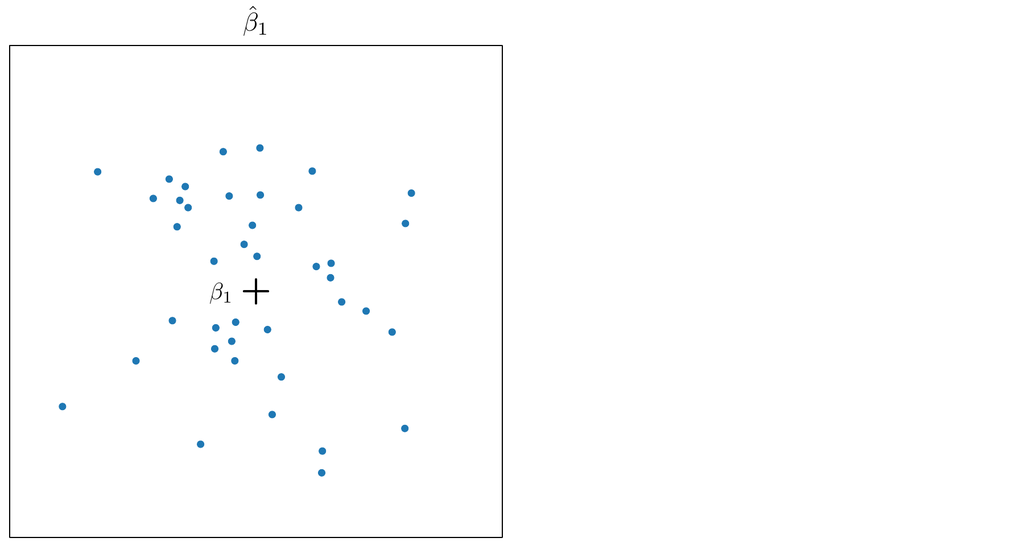

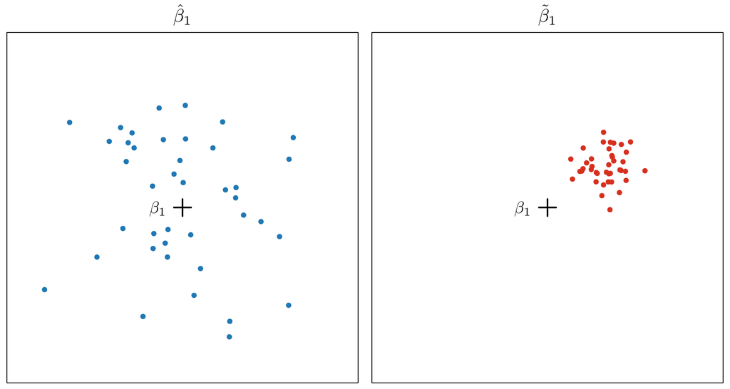

## Mean squared error (MSE)

- $\underset{1\times 1}{\hat\theta}$: estimator of $\underset{1\times 1}{\theta_0}$.
- Expected loss, add and subtract $\mathrm{E}\left[\hat\theta\right]$:
  $$\begin{aligned}
  \mathrm{E}\left[(\hat\theta - \theta_0)^2\right] &= \mathrm{E}\left[\big( \hat\theta - \mathrm{E}\left[\hat\theta\right] + \mathrm{E}\left[\hat\theta\right] - \theta_0 \big)^2\right] \\
  &= \mathrm{E}\left[(\hat\theta - \mathrm{E}\left[\hat\theta\right])^2\right] + (\mathrm{E}\left[\hat\theta\right] - \theta_0)^2 \\
  &\qquad + 2\, \mathrm{E}\left[(\hat\theta - \mathrm{E}\left[\hat\theta\right])(\mathrm{E}\left[\hat\theta\right] - \theta_0)\right]
  \end{aligned}$$
- Cross term, $\mathrm{E}\left[\hat\theta\right] - \theta_0$ not random:
  $$\begin{aligned}
  \mathrm{E}\left[(\hat\theta - \mathrm{E}\left[\hat\theta\right])(\mathrm{E}\left[\hat\theta\right] - \theta_0)\right] &= (\mathrm{E}\left[\hat\theta\right] - \theta_0)\, \underbrace{\mathrm{E}\left[\hat\theta - \mathrm{E}\left[\hat\theta\right]\right]}_{=\,0} \\
  &= 0
  \end{aligned}$$
- Therefore:
  $$\boxed{\ \underbrace{\mathrm{E}\left[(\hat\theta - \theta_0)^2\right]}_{\text{MSE}} = \underbrace{\mathrm{E}\left[(\hat\theta - \mathrm{E}\left[\hat\theta\right])^2\right]}_{\mathrm{Var}\left(\hat\theta\right)} + \underbrace{(\mathrm{E}\left[\hat\theta\right] - \theta_0)^2}_{\text{Bias}^2}\ }$$
- A biased estimator can have a smaller MSE.

# Estimated variances

## Two estimated variances

- Long regression, $\hat U = Y - X_1 \hat\beta_1 - X_2 \hat\beta_2$:
  $$\widehat{\mathrm{Var}}\big(\hat\beta_1 \mid X_1, X_2\big) = s^2 (X_1^\top M_2 X_1)^{-1}, \qquad s^2 = \frac{\hat U^\top \hat U}{n - k}$$
- Short regression, $\tilde U = Y - X_1 \tilde\beta_1$:
  $$\widehat{\mathrm{Var}}\big(\tilde\beta_1 \mid X_1, X_2\big) = \tilde s^2 (X_1^\top X_1)^{-1}, \qquad \tilde s^2 = \frac{\tilde U^\top \tilde U}{n - k_1}$$
- Standard errors, $j$-th entries:
  $$\begin{aligned}
  \text{std. err}\big(\hat\beta_{1,j}\big) &= \sqrt{s^2 \big[(X_1^\top M_2 X_1)^{-1}\big]_{jj}} \\
  \text{std. err}\big(\tilde\beta_{1,j}\big) &= \sqrt{\tilde s^2 \big[(X_1^\top X_1)^{-1}\big]_{jj}}
  \end{aligned}$$
- Third lecture: $\mathrm{E}\left[s^2 \mid X_1, X_2\right] = \sigma^2$.
- Sums of squared residuals, in every sample:
  $$\begin{aligned}
  \hat U^\top \hat U &= \|Y - X_1 \hat\beta_1 - X_2 \hat\beta_2\|^2 \\
  &\le \|Y - X_1 \tilde\beta_1\|^2 \\
  &= \tilde U^\top \tilde U
  \end{aligned}$$
- In terms of $s^2$ and $\tilde s^2$:
  $$\begin{aligned}
  s^2 &= \frac{\hat U^\top \hat U}{n - k} \\
  \tilde s^2 &= \frac{\tilde U^\top \tilde U}{n - k_1}
  \end{aligned}$$
- Two estimated variances, factor by factor:
  $$\begin{aligned}
  \widehat{\mathrm{Var}}\big(\hat\beta_1 \mid X_1, X_2\big) &= \underbrace{s^2}_{\mathrm{E}\left[s^2 \mid X_1, X_2\right] \,=\, \sigma^2}\ \underbrace{(X_1^\top M_2 X_1)^{-1}}_{\text{bigger}} \\
  \widehat{\mathrm{Var}}\big(\tilde\beta_1 \mid X_1, X_2\big) &= \underbrace{\tilde s^2}_{\mathrm{E}\left[\tilde s^2 \mid X_1, X_2\right] \,\ge\, \sigma^2}\ \underbrace{(X_1^\top X_1)^{-1}}_{\text{smaller}}
  \end{aligned}$$

## Proof that $\mathrm{E}[\tilde s^2 \mid X_1, X_2] \ge \sigma^2$

- $M_1$, third lecture:
  $$M_1 = I_n - X_1 (X_1^\top X_1)^{-1} X_1^\top$$
- $M_1$: symmetric, idempotent, p.s.d., $M_1 X_1 = 0$, $\operatorname{tr}(M_1) = n - k_1$.
- $\tilde U$ under the true model:
  $$\begin{aligned}
  \tilde U &= Y - X_1 \tilde\beta_1 \\
  &= M_1 Y \\
  &= M_1 \big( X_1 \beta_1 + X_2 \beta_2 + U \big) \\
  &= \underbrace{M_1 X_1}_{=\,0}\, \beta_1 + M_1 X_2 \beta_2 + M_1 U \\
  &= M_1 X_2 \beta_2 + M_1 U
  \end{aligned}$$
- We will use, for $a, b \in \mathbb{R}^n$:
  $$\begin{aligned}
  (a + b)^\top (a + b) &= a^\top a + b^\top b + \underbrace{b^\top a + a^\top b}_{=\,2 a^\top b} \\
  &= a^\top a + b^\top b + 2\, a^\top b
  \end{aligned}$$
- Sum of squared residuals:
  $$\begin{aligned}
  \tilde U^\top \tilde U &= \big( \underbrace{M_1 X_2 \beta_2}_{a} + \underbrace{M_1 U}_{b} \big)^\top \big( M_1 X_2 \beta_2 + M_1 U \big) \\
  &= \beta_2^\top X_2^\top M_1 X_2 \beta_2 + U^\top M_1 U + 2\, \beta_2^\top X_2^\top M_1 U \quad (M_1^\top M_1 = M_1)
  \end{aligned}$$
- Conditional mean of $\tilde U^\top \tilde U$ term by term, trace argument (third lecture):
  $$\begin{aligned}
  \mathrm{E}\left[\tilde U^\top \tilde U \mid X_1, X_2\right] &= \beta_2^\top X_2^\top M_1 X_2 \beta_2 + \underbrace{\mathrm{E}\left[U^\top M_1 U \mid X_1, X_2\right]}_{=\,\sigma^2 \operatorname{tr}(M_1)\,=\,\sigma^2 (n - k_1)} \\
  &\qquad + 2\, \beta_2^\top X_2^\top M_1\, \underbrace{\mathrm{E}\left[U \mid X_1, X_2\right]}_{=\,0} \\
  &= \beta_2^\top X_2^\top M_1 X_2 \beta_2 + \sigma^2 (n - k_1)
  \end{aligned}$$
- Divide by $n - k_1$:
  $$\begin{aligned}
  \mathrm{E}\left[\tilde s^2 \mid X_1, X_2\right] &= \frac{\mathrm{E}\left[\tilde U^\top \tilde U \mid X_1, X_2\right]}{n - k_1} \\
  &= \boxed{\ \sigma^2 + \frac{\beta_2^\top X_2^\top M_1 X_2 \beta_2}{n - k_1}\ } \\
  &\ge \sigma^2 = \mathrm{E}\left[s^2 \mid X_1, X_2\right]
  \end{aligned}$$
- $\tilde s^2$: biased upward in general.

# Including an irrelevant regressor

## Irrelevant regressor: both estimators unbiased

- True model, estimated by the long regression $Y \mid X_1, X_2$:
  $$\begin{aligned}
  & Y = X_1 \beta_1 + X_2 \beta_2 + U, \quad \beta_2 = 0 \\
  \Longrightarrow\quad & Y = X_1 \beta_1 + U
  \end{aligned}$$
- Short regression:
  $$\begin{aligned}
  \tilde\beta_1 &= (X_1^\top X_1)^{-1} X_1^\top \big( X_1 \beta_1 + U \big) \\
  &= \beta_1 + (X_1^\top X_1)^{-1} X_1^\top U
  \end{aligned}$$
- Conditional mean of $\tilde\beta_1$, by Assumption 2:
  $$\mathrm{E}\left[\tilde\beta_1 \mid X_1, X_2\right] = \beta_1$$
- Long regression:
  $$\begin{aligned}
  \hat\beta_1 &= (X_1^\top M_2 X_1)^{-1} X_1^\top M_2 \big( X_1 \beta_1 + U \big) \\
  &= \beta_1 + (X_1^\top M_2 X_1)^{-1} X_1^\top M_2 U
  \end{aligned}$$
- Conditional mean of $\hat\beta_1$, by Assumption 2:
  $$\mathrm{E}\left[\hat\beta_1 \mid X_1, X_2\right] = \beta_1$$

## Irrelevant regressor: variances

- Same conditional variances as for $\beta_2 \ne 0$, by Assumption 3:
  $$\begin{aligned}
  \mathrm{Var}\left(\hat\beta_1 \mid X_1, X_2\right) &= \sigma^2 (X_1^\top M_2 X_1)^{-1} \\
  \mathrm{Var}\left(\tilde\beta_1 \mid X_1, X_2\right) &= \sigma^2 (X_1^\top X_1)^{-1}
  \end{aligned}$$
- By the Claim on the larger variance of the long regression:
  $$\mathrm{Var}\left(\hat\beta_1 \mid X_1, X_2\right) - \mathrm{Var}\left(\tilde\beta_1 \mid X_1, X_2\right) \ \ge\ 0$$
- $\tilde s^2$ and $s^2$ both unbiased, trace argument, $\operatorname{tr}(M_1) = n - k_1$, $\operatorname{tr}(M_X) = n - k$:
  $$\mathrm{E}\left[\tilde s^2 \mid X_1, X_2\right] = \mathrm{E}\left[s^2 \mid X_1, X_2\right] = \sigma^2$$

## Two cases: $\beta_2 \ne 0$ and $\beta_2 = 0$

- Suppose $X_1^\top X_2 \ne 0$:
  $$\begin{aligned}
  \text{a. } \beta_2 \ne 0 \ \Longrightarrow\ & \tilde\beta_1:\ \text{biased in general} \\
  \text{b. } \beta_2 = 0 \ \Longrightarrow\ & \hat\beta_1:\ \text{larger variance than } \tilde\beta_1
  \end{aligned}$$

# Orthogonal regressors

## Orthogonal blocks: $M_2 X_1 = X_1$

- Suppose $X_1^\top X_2 = 0$:
  $$X_1^\top X_2 = 0 \quad \Longleftrightarrow \quad \text{columns of } X_1 \in S^\perp(X_2)$$
- Then:
  $$\begin{aligned}
  M_2 X_1 &= X_1 - P_2 X_1 \\
  &= X_1 - X_2 (X_2^\top X_2)^{-1} \underbrace{X_2^\top X_1}_{=\,0} \\
  &= X_1
  \end{aligned}$$
- Exactly orthogonal dummies, high school (HS) and college (C), $k_1 = k_2 = 1$:
  $$\begin{aligned}
  X_{i,1} &= \mathbf{1}(\text{Education}_i = \text{HS}) \\
  X_{i,2} &= \mathbf{1}(\text{Education}_i = \text{C})
  \end{aligned}$$
- Never both equal to $1$:
  $$\begin{aligned}
  & X_{i,1}\, X_{i,2} = 0 \quad \text{for every } i \\
  \Longrightarrow\quad & X_1^\top X_2 = \sum_{i=1}^n X_{i,1}\, X_{i,2} = 0
  \end{aligned}$$

## Same estimate, same variance

- Estimators coincide, by $M_2^\top = M_2$:
  $$\begin{aligned}
  \hat\beta_1 &= \big( X_1^\top \underbrace{M_2 X_1}_{=\,X_1} \big)^{-1}\, \underbrace{X_1^\top M_2}_{=\,(M_2 X_1)^\top =\, X_1^\top}\, Y \\
  &= (X_1^\top X_1)^{-1} X_1^\top Y \\
  &= \tilde\beta_1
  \end{aligned}$$
- Both unbiased:
  $$\mathrm{E}\left[\hat\beta_1 \mid X_1, X_2\right] = \mathrm{E}\left[\tilde\beta_1 \mid X_1, X_2\right] = \beta_1$$
- Equal conditional variances:
  $$\begin{aligned}
  \mathrm{Var}\left(\hat\beta_1 \mid X_1, X_2\right) &= \sigma^2 (X_1^\top M_2 X_1)^{-1} \\
  &= \sigma^2 (X_1^\top X_1)^{-1} \\
  &= \mathrm{Var}\left(\tilde\beta_1 \mid X_1, X_2\right)
  \end{aligned}$$
- $X_1^\top M_2 X_1$ against $X_1^\top X_1$:
  $$\begin{aligned}
  X_1^\top X_1 - X_1^\top M_2 X_1 &\ge 0 \\
  X_1^\top M_2 X_1 &= X_1^\top X_1 \quad \text{if } X_1^\top X_2 = 0
  \end{aligned}$$
- Adding $X_2$ with $X_1^\top X_2 = 0 \ \Longrightarrow\$ variance unchanged.

## Which regression to run

- $X_1^\top X_2 = 0$; two options: long $Y \mid X_1, X_2$, short $Y \mid X_1$.
- Short regression’s error:
  $$Y = X_1 \beta_1 + \underbrace{X_2 \beta_2 + U}_{V}$$
- $M_1 X_2 = X_2$, by the same chain as $M_2 X_1 = X_1$.
- Short regression’s residuals keep $X_2 \beta_2$:
  $$\begin{aligned}
  \tilde U &= M_1 X_2 \beta_2 + M_1 U \\
  &= X_2 \beta_2 + M_1 U
  \end{aligned}$$
- $\tilde U$ in terms of the long regression’s fit, $\hat\beta_1 = \tilde\beta_1$:
  $$\begin{aligned}
  \tilde U &= Y - X_1 \tilde\beta_1 \\
  &= Y - X_1 \hat\beta_1 \\
  &= X_2 \hat\beta_2 + \hat U
  \end{aligned}$$
- $X_2 \hat\beta_2$: not removed from $\tilde U$.

## Controlling for orthogonal $X_2$: smaller estimated variance in general

- $\mathrm{E}\left[\tilde s^2 \mid X_1, X_2\right]$ with $M_1 X_2 = X_2$:
  $$\begin{aligned}
  \mathrm{E}\left[\tilde s^2 \mid X_1, X_2\right] &= \sigma^2 + \frac{\beta_2^\top X_2^\top M_1 X_2 \beta_2}{n - k_1} \\
  &= \sigma^2 + \frac{\beta_2^\top X_2^\top X_2 \beta_2}{n - k_1} \\
  &= \sigma^2 + \frac{\|X_2 \beta_2\|^2}{n - k_1} \\
  &> \sigma^2 = \mathrm{E}\left[s^2 \mid X_1, X_2\right] \quad \text{if } X_2 \beta_2 \ne 0
  \end{aligned}$$
- Estimated variances, same estimate $\hat\beta_1 = \tilde\beta_1$:
  $$\begin{aligned}
  \widehat{\mathrm{Var}}\big(\hat\beta_1 \mid X_1, X_2\big) &= s^2 (X_1^\top X_1)^{-1} \\
  \widehat{\mathrm{Var}}\big(\tilde\beta_1 \mid X_1, X_2\big) &= \tilde s^2 (X_1^\top X_1)^{-1}
  \end{aligned}$$
- Short regression’s estimated variance: biased upward if $X_2 \beta_2 \ne 0$.
- $\Longrightarrow$ Use $\hat\beta_1$, the long regression.
- Fourth and fifth lectures: std. err $\downarrow \Longrightarrow$ confidence interval length $\downarrow$, power $\uparrow$.

# Summary

## Omitted and irrelevant regressors

- In every sample: $\tilde\beta_1 = \hat\beta_1 + (X_1^\top X_1)^{-1} X_1^\top X_2 \hat\beta_2$; equal if $X_1^\top X_2 = 0$.
- $\mathrm{E}\left[\tilde\beta_1 \mid X_1, X_2\right] = \beta_1 + (X_1^\top X_1)^{-1} X_1^\top X_2 \beta_2$, bias $= 0$ if $\beta_2 = 0$ or $X_1^\top X_2 = 0$; $\mathrm{E}\left[\hat\beta_1 \mid X_1, X_2\right] = \beta_1$.
- $\mathrm{Var}\left(\hat\beta_1 \mid X_1, X_2\right) = \sigma^2 (X_1^\top M_2 X_1)^{-1} = \sigma^2 (\tilde X_1^\top \tilde X_1)^{-1}$, $\mathrm{Var}\left(\tilde\beta_1 \mid X_1, X_2\right) = \sigma^2 (X_1^\top X_1)^{-1}$.
- $X_1^\top X_1 - X_1^\top M_2 X_1 = X_1^\top P_2 X_1 \ge 0 \Longrightarrow \mathrm{Var}\left(\hat\beta_1 \mid X_1, X_2\right) - \mathrm{Var}\left(\tilde\beta_1 \mid X_1, X_2\right) \ge 0$.
- $\beta_2 \ne 0 \Longrightarrow$ $\hat\beta_1$ unbiased, larger variance; $\tilde\beta_1$ biased in general, smaller variance.
- $\text{MSE} = \mathrm{Var}\left(\hat\theta\right) + \text{Bias}^2$.
- $\beta_2 = 0 \Longrightarrow$ both unbiased, $\hat\beta_1$ larger variance; $\mathrm{E}\left[s^2 \mid X_1, X_2\right] = \mathrm{E}\left[\tilde s^2 \mid X_1, X_2\right] = \sigma^2$.

## Estimated variances and orthogonal regressors

- $\widehat{\mathrm{Var}}\big(\hat\beta_1 \mid X_1, X_2\big) = s^2 (X_1^\top M_2 X_1)^{-1}$, $s^2 = \hat U^\top \hat U / (n - k)$; $\widehat{\mathrm{Var}}\big(\tilde\beta_1 \mid X_1, X_2\big) = \tilde s^2 (X_1^\top X_1)^{-1}$, $\tilde s^2 = \tilde U^\top \tilde U / (n - k_1)$; $\hat U^\top \hat U \le \tilde U^\top \tilde U$.
- $\tilde U = M_1 X_2 \beta_2 + M_1 U$; $\mathrm{E}\left[\tilde s^2 \mid X_1, X_2\right] = \sigma^2 + \beta_2^\top X_2^\top M_1 X_2 \beta_2 / (n - k_1) \ge \sigma^2 = \mathrm{E}\left[s^2 \mid X_1, X_2\right]$.
- $X_1^\top X_2 = 0 \Longrightarrow M_2 X_1 = X_1 \Longrightarrow \hat\beta_1 = \tilde\beta_1$ and $\mathrm{Var}\left(\hat\beta_1 \mid X_1, X_2\right) = \mathrm{Var}\left(\tilde\beta_1 \mid X_1, X_2\right) = \sigma^2 (X_1^\top X_1)^{-1}$.
- $X_1^\top X_2 = 0$, $X_2 \beta_2 \ne 0 \Longrightarrow$ $\tilde U = X_2 \beta_2 + M_1 U$, $\mathrm{E}\left[\tilde s^2 \mid X_1, X_2\right] = \sigma^2 + \beta_2^\top X_2^\top X_2 \beta_2 / (n - k_1) > \sigma^2 \Longrightarrow$ use $\hat\beta_1$, the long regression.